# Data Analytics Assignment 3

```r
nyt2 <- read.csv("G:\\My Drive\\RPI\\Data Analytics\\nyt2.csv")
nyt3 <- read.csv("G:\\My Drive\\RPI\\Data Analytics\\nyt3.csv")
nyt4 <- read.csv("G:\\My Drive\\RPI\\Data Analytics\\nyt4.csv")
nyt5 <- read.csv("G:\\My Drive\\RPI\\Data Analytics\\nyt5.csv")
nyt6 <- read.csv("G:\\My Drive\\RPI\\Data Analytics\\nyt6.csv")
```

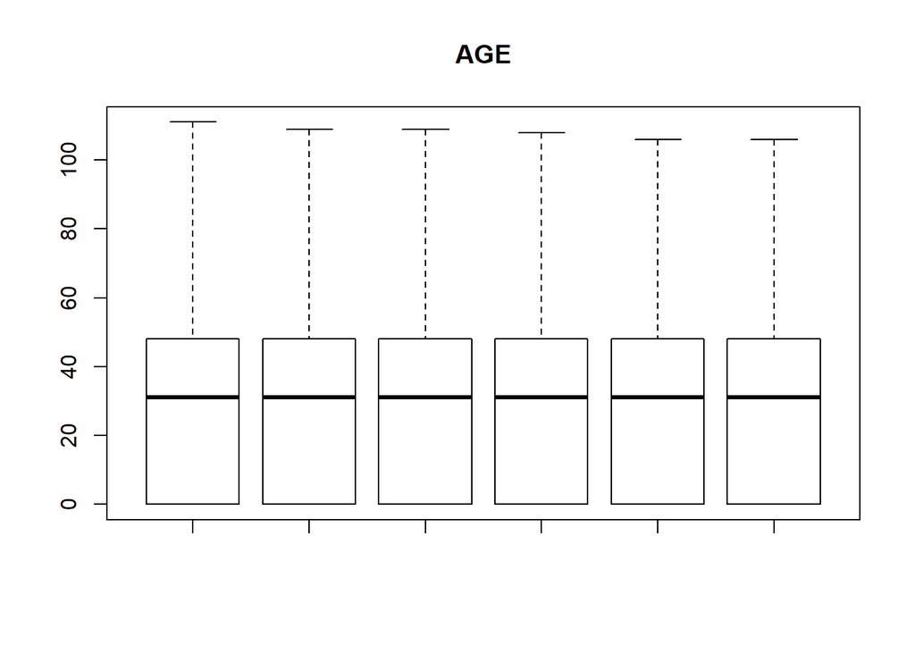

```r
boxplot(nyt2$Age, nyt3$Age, nyt3$Age, nyt4$Age, nyt5$Age, nyt6$Age, main = "AGE")
```

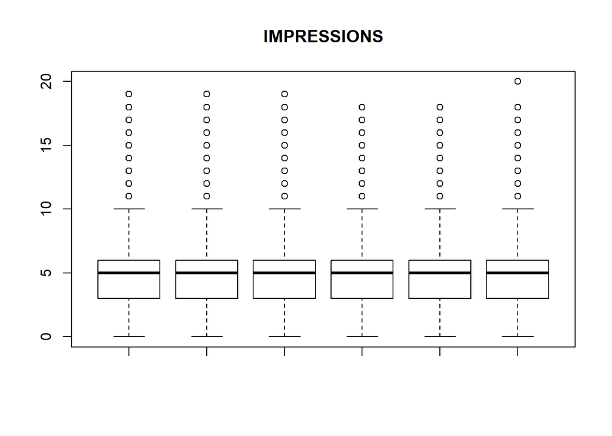

```r
boxplot(nyt2$Impressions, nyt3$Impressions, nyt3$Impressions, nyt4$Impressions, nyt5$Impressions, nyt6$Impressions, main = "IMPRESSIONS")
```

The distribution of ages is essentially constant across the datasets. The median age is around 30, but the distribution is skewed towards the higher numbers. The distribution of impressions is also essentially constant across the different datasets. The median number of impressions is around 5 and it is also skewed to the higher numbers.

(b,c) We will first analyze the ages then the impressions. Each variable will go through parts b and c.

(Age)

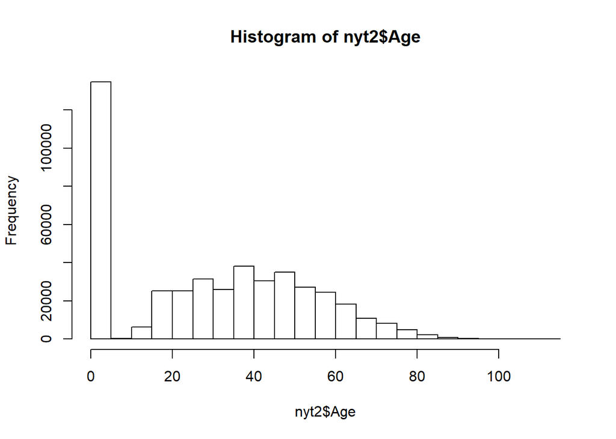

```r
hist(nyt2$Age)
```

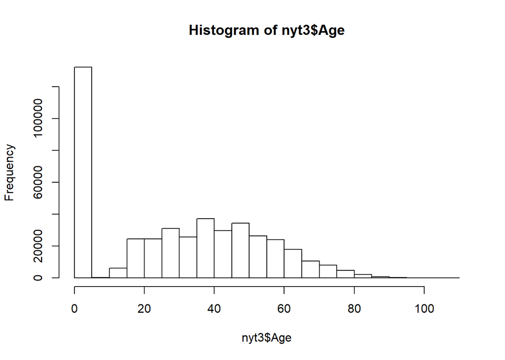

```r
hist(nyt3$Age)
```

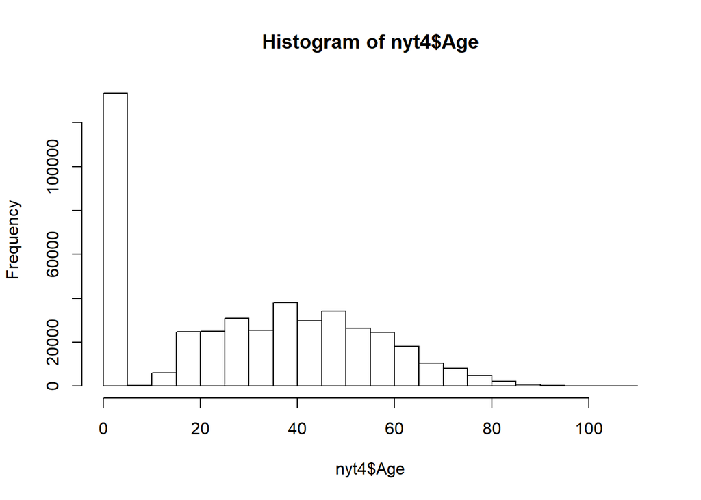

```r
hist(nyt4$Age)
```

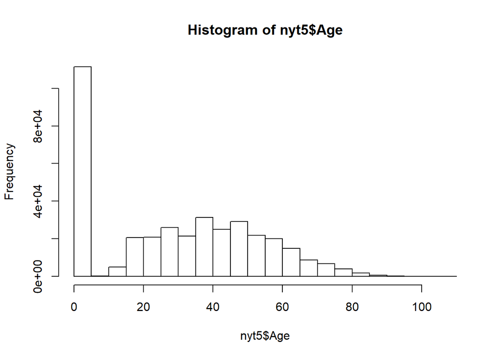

```r
hist(nyt5$Age)
```

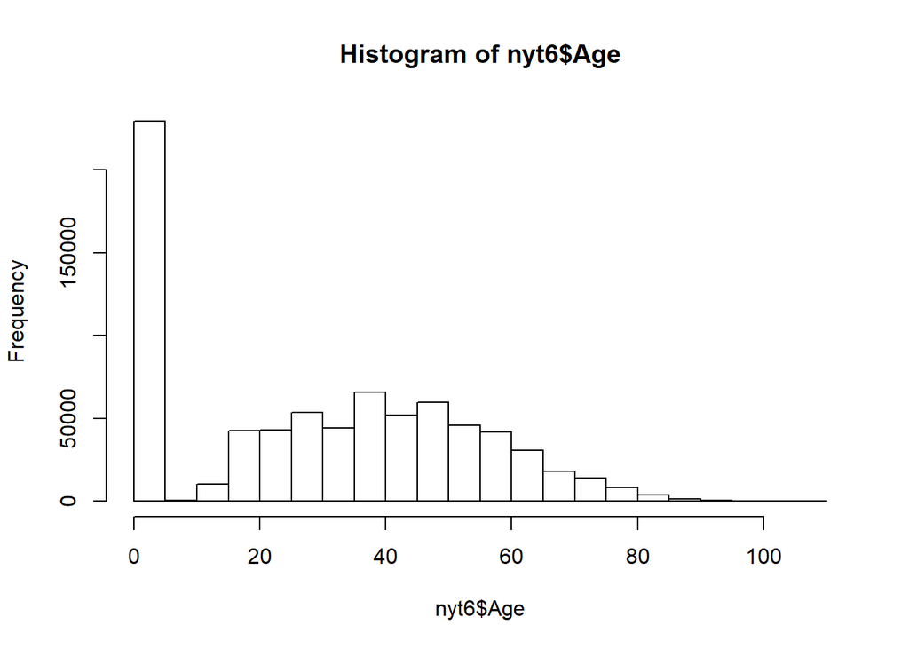

```r
hist(nyt6$Age)
```

A large number of the ages are zero. This probably means that missing ages are represented by a zero. We will filter out the zeroes.

```r
library(fitdistrplus)
fit2 <- fitdist(nyt2$Age[nyt2$Age > 0], "gamma")
fit3 <- fitdist(nyt3$Age[nyt3$Age > 0], "gamma")
fit4 <- fitdist(nyt4$Age[nyt4$Age > 0], "gamma")
fit5 <- fitdist(nyt5$Age[nyt5$Age > 0], "gamma")
fit6 <- fitdist(nyt6$Age[nyt6$Age > 0], "gamma")
rbind(fit2$estimate,fit3$estimate,fit4$estimate,fit5$estimate,fit6$estimate)
```

```
##         shape      rate
## [1,] 6.142596 0.1458999
## [2,] 6.142186 0.1459082
## [3,] 6.145279 0.1459731
## [4,] 6.148723 0.1460786
## [5,] 6.184788 0.1469447
```

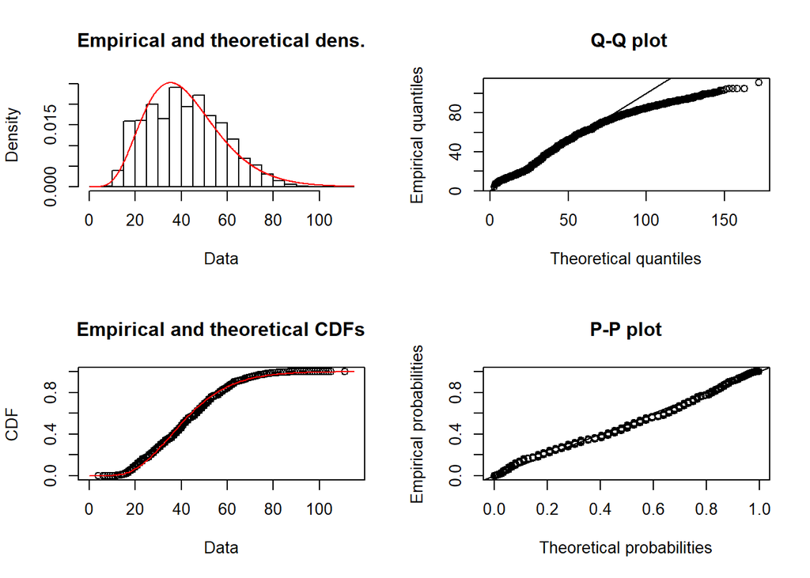

```r
plotdist(nyt2$Age[nyt2$Age > 0],"gamma",para=as.list(fit2$estimate))
```

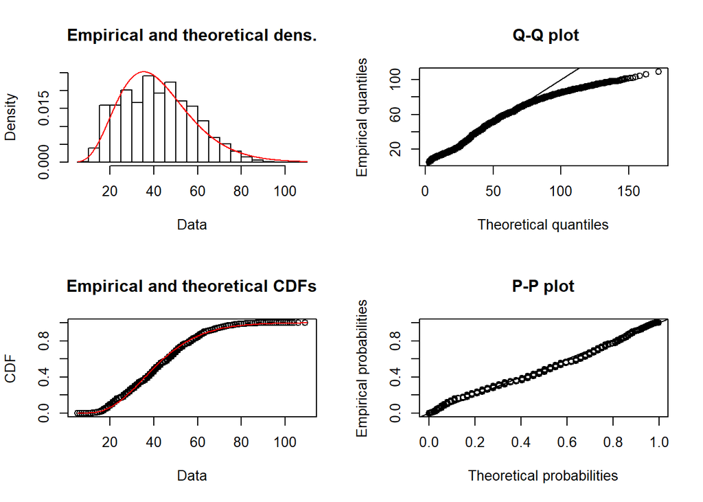

```r
plotdist(nyt3$Age[nyt3$Age > 0],"gamma",para=as.list(fit3$estimate))
```

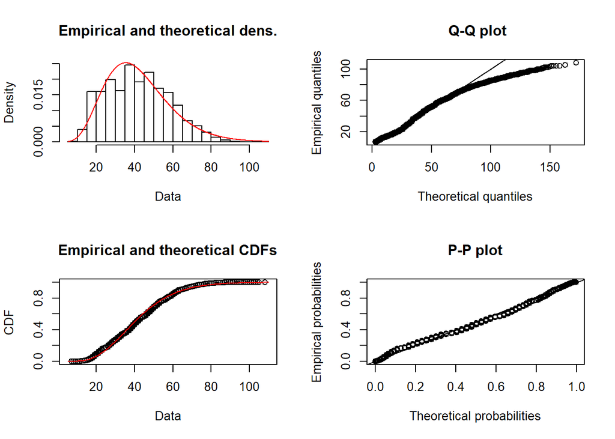

```r
plotdist(nyt4$Age[nyt4$Age > 0],"gamma",para=as.list(fit4$estimate))
```

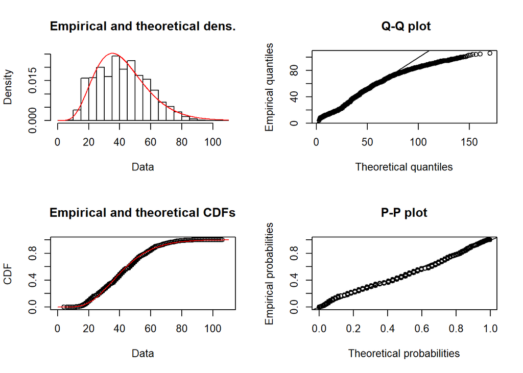

```r
plotdist(nyt5$Age[nyt5$Age > 0],"gamma",para=as.list(fit5$estimate))
```

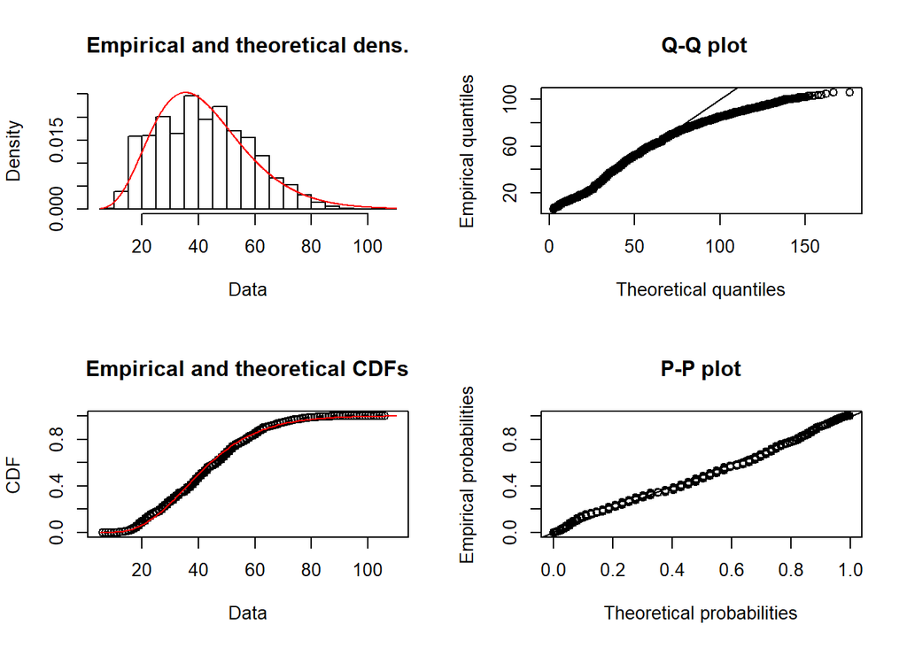

```r
plotdist(nyt6$Age[nyt6$Age > 0],"gamma",para=as.list(fit6$estimate))
```

The distribution of ages is modeled well by the Gamma distribution. We can see that the distribution is skewed to the right in the QQ-plot; the empirical quantiles start to fall behind the theoretical quantiles. The PP-plot shows that the Gamma distribution is a good fit for the data as it is mostly linear. We can see that the Gamma distribution underestimates the number of people from 20-40.

(Impressions)

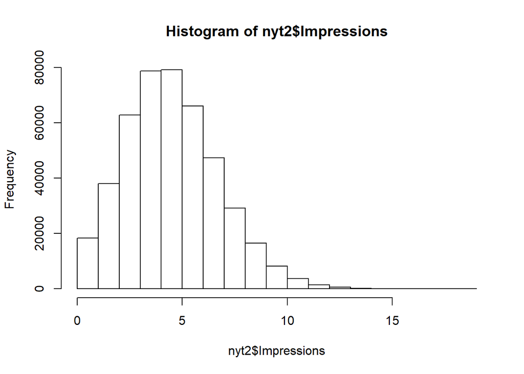

```r
hist(nyt2$Impressions)
```

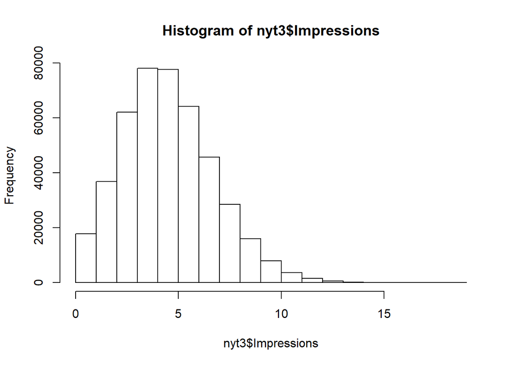

```r
hist(nyt3$Impressions)
```

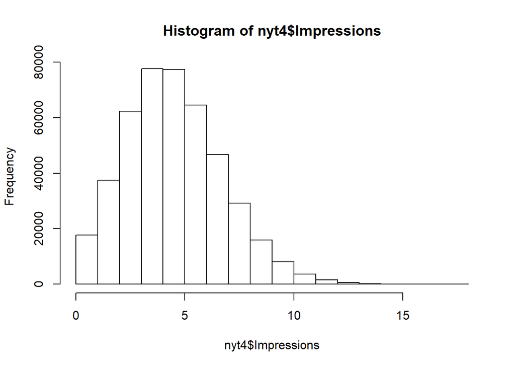

```r
hist(nyt4$Impressions)
```

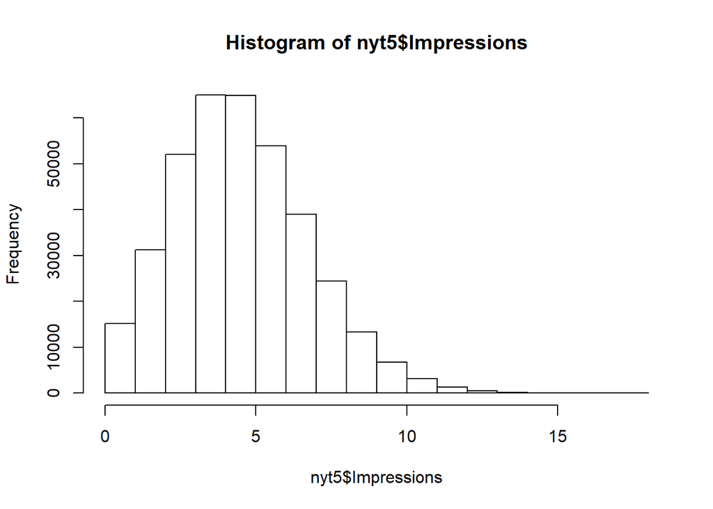

```r
hist(nyt5$Impressions)
```